# Importación de librerías y lectura de datos

```python
import pandas as pd
import numpy as np
import matplotlib.pyplot as plt
import seaborn as sns
from google.colab import drive
```

```python
# Conectamos con nuestro Google Drive
# drive.mount('/content/drive')
```

```python
# !mkdir EXABY
```

```python
# !unzip /content/drive/MyDrive/EXABY/DATA_SET.zip -d EXABY
```

```python
df_anuncios = pd.read_csv('EXABY/DATA_SET/Anuncios_usados.csv')
df_anuncios.shape
```

```
(268252, 23)
```

Número de nulls

```python
df_anuncios.isnull().sum()
```

```
Maker               0
 Genmodel           0
 Genmodel_ID        0
Adv_ID              0
Color           21875
Reg_year            7
Bodytype          954
Runned_Miles     1055
Engin_size       2064
Gearbox           167
Fuel_type         409
Engine_power    31810
Annual_Tax      46673
Wheelbase       27997
Height          27800
Width           28079
Length          27800
Average_mpg     41932
Top_speed       43601
Seat_num         6474
Door_num         4552
Ad_Date             0
Price_USD       16009
dtype: int64
```

```python
df_anuncios.dtypes
df_anuncios.rename(columns={' Genmodel': 'Genmodel',  ' Genmodel_ID': 'Genmodel_ID'}, inplace=True)
```

Eliminamos ciertas columnas que no aportan valor o que podemos obtener de otras tablas:

```python
df_anuncios_clean = df_anuncios.drop(columns = ['Maker', 'Color', 'Genmodel'])
```

Limpiamos los datos duplicados y las filas que tienen columnas que no pueden no tener datos y no se pueden sustituir:

```python
df_anuncios_clean = df_anuncios_clean.drop_duplicates()
df_anuncios_clean = df_anuncios_clean[df_anuncios_clean['Reg_year'].notna()]
df_anuncios_clean = df_anuncios_clean[df_anuncios_clean['Runned_Miles'].notna()]
```

Antes de proceder con la limpieza, procedemos a ordenar el dataset por identificador de modelo, año de creación y millas recorridas

```python
df_anuncios_clean=df_anuncios_clean.sort_values(['Genmodel_ID', 'Reg_year','Runned_Miles'], ascending=[True, True, True])
```

Limpiamos las columnas que puedan tener caracteres no deseados:

```python
df_anuncios_clean['Engin_size'] = df_anuncios_clean['Engin_size'].str[:-1]
df_anuncios_clean['Engin_size'] = pd.to_numeric(df_anuncios_clean['Engin_size'])
df_anuncios_clean['Engin_size'].fillna(method='ffill', inplace=True)
```

```python
fill_columns = ['Gearbox', 'Fuel_type', 'Seat_num', 'Door_num', 'Bodytype']
for c in fill_columns:
  df_anuncios_clean[df_anuncios_clean[c]==""] = np.NaN
  df_anuncios_clean[c].fillna(method='ffill', inplace=True)
```

```python
arr_cols = ['Engine_power','Wheelbase','Height','Width','Length']

for c in arr_cols:
    df_anuncios_clean[c] = pd.to_numeric(df_anuncios_clean[c])
    df_anuncios_clean.groupby('Genmodel_ID')[c].mean()
```

Limpieza de columnas con caracteres raros:

```python
df_anuncios_clean['Annual_Tax'].unique()
```

```
array([nan, ' 315', ' 555', ' 140*', ' 230', ' 540', ' 545', ' 195',
       ' 250', ' 290', ' 140', ' 120', ' 30', ' 155', ' 0', ' 20', '*',
       ' 10', ' 240', ' 220', ' 130*', ' 280', ' 530', ' 110', ' 0*',
       ' 145', ' 185', ' 130', ' 305'], dtype=object)
```

Salvamos los datos con caracteres raros, eliminamos los na

```python
conflict_cols = ['Annual_Tax', 'Average_mpg','Top_speed']

for c in conflict_cols:
    df_anuncios_clean[c] = df_anuncios_clean[c].str.extract('(\d+)', expand=False)
    df_anuncios_clean[c] = pd.to_numeric(df_anuncios_clean[c])
    df_anuncios_clean.dropna(inplace=True)
```

Tratamos la columna refrente a fecha de ventay al precio:

```python
import re
df_anuncios_clean['Ad_Date'] =  df_anuncios_clean['Ad_Date'].apply(lambda x: re.sub('[^A-Za-z0-9]+','', str(x)))
```

```python
df_anuncios_clean['Price_USD'] = df_anuncios_clean['Price_USD'].round(3)
```

# Análisis exploratorio: tabla 'Versiones'

```python
pd.set_option("max_rows", 10)
df_versiones = pd.read_csv('EXABY/DATA_SET/Versiones.csv')
```

## Detección de nulos

Vemos ahora cuántos de los campos son *null* y cuántos *na* y observamos que todas las variables tienen valor para todas las filas.

```python
df_versiones.isnull().sum()
```

```
Genmodel_ID     0
Maker           0
Genmodel        0
Trim            0
Year            0
Price           0
Gas_emission    0
Fuel_type       0
Engine_size     0
dtype: int64
```

Obtenemos datos de las variables numéricas para asegurarnos de que los datos tienen valores coherentes.

```python
df_versiones.describe()
```

|  | Year | Price | Gas_emission | Engine_size |
| --- | --- | --- | --- | --- |
| count | 335562.00000 | 335562.000000 | 335562.000000 | 335562.000000 |
| mean | 2010.14217 | 25437.295144 | 160.947479 | 1962.726104 |
| std | 5.41368 | 16954.935215 | 49.954728 | 711.154778 |
| min | 1998.00000 | 4499.000000 | 0.000000 | 0.000000 |
| 25% | 2006.00000 | 16999.000000 | 126.000000 | 1587.000000 |
| 50% | 2011.00000 | 22390.000000 | 152.000000 | 1968.000000 |
| 75% | 2015.00000 | 29455.000000 | 186.000000 | 1998.000000 |
| max | 2021.00000 | 434000.000000 | 570.000000 | 6761.000000 |

## Detección de outliers

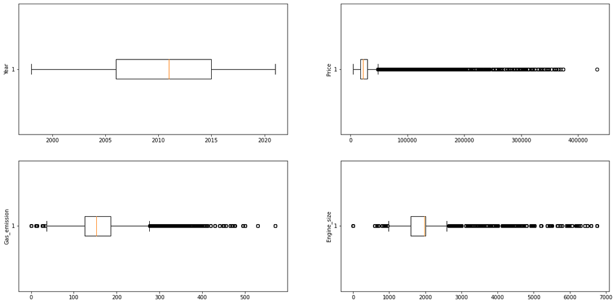

```python
fig = plt.figure(figsize = (20, 10))
numeric = ['Year', 'Price', 'Gas_emission', 'Engine_size']
for i in range(len(numeric)):
    p = fig.add_subplot(2, 2, i+1)
    plt.boxplot(df_versiones[numeric[i]], vert = False)
    p.set_ylabel(numeric[i])
```

En esta gráfica se señalan posibles outliers mediante el método de los intercuartiles. Podemos observar que el único outlier real es el que se encuentra en precios, así que lo eliminaremos.

```python
df_versiones = df_versiones[df_versiones['Price'] < 400000]
```

## Reducción de número de variables:

Eliminamos las columnas que nos aportan datos redundantes. Éstas son *Maker* y *Genmodel*, que son redundantes con _Genmodel*ID*. Posteriormente agrupamos los las instancias del mismo modelo, mismo año, y mismo combustible, haciedno la media de los valores de emisiones, precio y tamaño de motor.

```python
df_versiones = df_versiones.drop(columns= ['Maker', 'Genmodel'])
df_versiones_grouped = df_versiones.groupby(['Genmodel_ID', 'Year', 'Fuel_type']).mean()
df_versiones_grouped.reset_index(inplace = True)
df_versiones_grouped
```

|  | Genmodel_ID | Year | Fuel_type | Price | Gas_emission | Engine_size |
| --- | --- | --- | --- | --- | --- | --- |
| 0 | 10_1 | 1998 | Petrol | 145000.000000 | 390.000000 | 4398.000000 |
| 1 | 10_1 | 1999 | Petrol | 146333.333333 | 412.000000 | 5182.000000 |
| 2 | 10_1 | 2000 | Petrol | 156580.000000 | 429.600000 | 5809.200000 |
| 3 | 10_1 | 2001 | Petrol | 165380.000000 | 351.600000 | 6279.600000 |
| 4 | 10_1 | 2002 | Petrol | 172529.100000 | 426.000000 | 6750.000000 |
| ... | ... | ... | ... | ... | ... | ... |
| 10445 | 96_9 | 2010 | Petrol | 22422.073171 | 185.268293 | 2120.317073 |
| 10446 | 96_9 | 2011 | Diesel | 24655.368421 | 135.273684 | 1857.031579 |
| 10447 | 96_9 | 2011 | Petrol | 22681.964286 | 186.857143 | 2156.642857 |
| 10448 | 96_9 | 2012 | Diesel | 25511.805556 | 133.583333 | 1866.222222 |
| 10449 | 96_9 | 2012 | Petrol | 22130.555556 | 183.777778 | 2115.000000 |

10450 rows × 6 columns

## Codificación de variables categóricas

A continuación codificamos la variable categórica _Fuel*type* mediante la codificación One Hot.

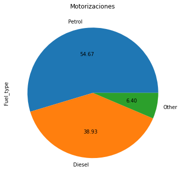

```python
df_versiones_grouped['Fuel_type'].value_counts().plot(kind='pie', autopct='%.2f', figsize=(6,6), title ='Motorizaciones')
```

```python
df_versiones_grouped.loc[df_versiones_grouped["Fuel_type"] == "Electric Diesel REX"] = 'Other'
df_versiones_grouped
```

|  | Genmodel_ID | Year | Fuel_type | Price | Gas_emission | Engine_size |
| --- | --- | --- | --- | --- | --- | --- |
| 0 | 10_1 | 1998 | Petrol | 145000.0 | 390.0 | 4398.0 |
| 1 | 10_1 | 1999 | Petrol | 146333.333333 | 412.0 | 5182.0 |
| 2 | 10_1 | 2000 | Petrol | 156580.0 | 429.6 | 5809.2 |
| 3 | 10_1 | 2001 | Petrol | 165380.0 | 351.6 | 6279.6 |
| 4 | 10_1 | 2002 | Petrol | 172529.1 | 426.0 | 6750.0 |
| ... | ... | ... | ... | ... | ... | ... |
| 10445 | 96_9 | 2010 | Petrol | 22422.073171 | 185.268293 | 2120.317073 |
| 10446 | 96_9 | 2011 | Diesel | 24655.368421 | 135.273684 | 1857.031579 |
| 10447 | 96_9 | 2011 | Petrol | 22681.964286 | 186.857143 | 2156.642857 |
| 10448 | 96_9 | 2012 | Diesel | 25511.805556 | 133.583333 | 1866.222222 |
| 10449 | 96_9 | 2012 | Petrol | 22130.555556 | 183.777778 | 2115.0 |

10450 rows × 6 columns

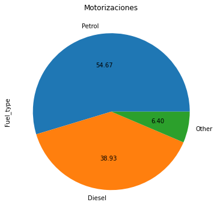

```python
df_versiones_grouped['Fuel_type'].value_counts().plot(kind='pie', autopct='%.2f', figsize=(6,6), title ='Motorizaciones')
```

```python
cat_grouped = pd.get_dummies(df_versiones_grouped[['Fuel_type']])
df_versiones_grouped_onehot = pd.concat([df_versiones_grouped, cat_grouped], axis = 1).drop(columns= ['Fuel_type'])
df_versiones_grouped_onehot
```

|  | Genmodel_ID | Year | Price | Gas_emission | Engine_size | Fuel_type_Diesel | Fuel_type_Other | Fuel_type_Petrol |
| --- | --- | --- | --- | --- | --- | --- | --- | --- |
| 0 | 10_1 | 1998 | 145000.0 | 390.0 | 4398.0 | 0 | 0 | 1 |
| 1 | 10_1 | 1999 | 146333.333333 | 412.0 | 5182.0 | 0 | 0 | 1 |
| 2 | 10_1 | 2000 | 156580.0 | 429.6 | 5809.2 | 0 | 0 | 1 |
| 3 | 10_1 | 2001 | 165380.0 | 351.6 | 6279.6 | 0 | 0 | 1 |
| 4 | 10_1 | 2002 | 172529.1 | 426.0 | 6750.0 | 0 | 0 | 1 |
| ... | ... | ... | ... | ... | ... | ... | ... | ... |
| 10445 | 96_9 | 2010 | 22422.073171 | 185.268293 | 2120.317073 | 0 | 0 | 1 |
| 10446 | 96_9 | 2011 | 24655.368421 | 135.273684 | 1857.031579 | 1 | 0 | 0 |
| 10447 | 96_9 | 2011 | 22681.964286 | 186.857143 | 2156.642857 | 0 | 0 | 1 |
| 10448 | 96_9 | 2012 | 25511.805556 | 133.583333 | 1866.222222 | 1 | 0 | 0 |
| 10449 | 96_9 | 2012 | 22130.555556 | 183.777778 | 2115.0 | 0 | 0 | 1 |

10450 rows × 8 columns

## Distribución de variables numéricas

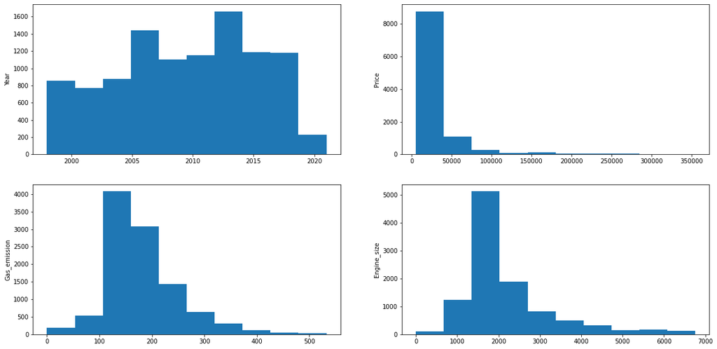

```python
fig = plt.figure(figsize = (20, 10))
for i in range(1, 5):
    p = fig.add_subplot(2,2, i)
    df_versiones_grouped_onehot[df_versiones_grouped_onehot.columns[i]].plot.hist(ax=p)
    p.set_ylabel(df_versiones_grouped_onehot.columns[i])
```

## Procedemos a fusionar ambas tablas:

```python
df_versiones_grouped.columns
```

```
Index(['Genmodel_ID', 'Year', 'Fuel_type', 'Price', 'Gas_emission',
       'Engine_size'],
      dtype='object')
```

```python
df_anuncios_clean.columns
```

```
Index(['Genmodel_ID', 'Adv_ID', 'Reg_year', 'Bodytype', 'Runned_Miles',
       'Engin_size', 'Gearbox', 'Fuel_type', 'Engine_power', 'Annual_Tax',
       'Wheelbase', 'Height', 'Width', 'Length', 'Average_mpg', 'Top_speed',
       'Seat_num', 'Door_num', 'Ad_Date', 'Price_USD'],
      dtype='object')
```

Ajustamos los nombres de las columnas:

```python
df_versiones_grouped.rename(columns = {'Year':'Reg_year'}, inplace=True)
```

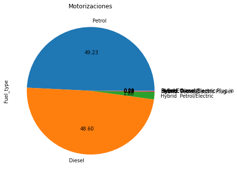

```python
df_anuncios_clean['Fuel_type'].value_counts().plot(kind='pie', autopct='%.2f', figsize=(6,6), title ='Motorizaciones')
```

```python
df_anuncios_clean['Fuel_type'].unique()
```

```
array(['Petrol', 'Diesel', 'Hybrid  Diesel/Electric', 'Bi Fuel',
       'Petrol Ethanol', 'Hybrid  Petrol/Electric', 'Electric',
       'Hybrid  Petrol/Electric Plug-in',
       'Hybrid  Diesel/Electric Plug-in'], dtype=object)
```

```python
for fuel in list(df_anuncios_clean['Fuel_type'].unique()):
  if fuel != 'Petrol' and fuel != 'Diesel':
    df_anuncios_clean.loc[df_anuncios_clean["Fuel_type"] == fuel] = 'Other'

df_anuncios_clean
```

|  | Genmodel_ID | Adv_ID | Reg_year | Bodytype | Runned_Miles | Engin_size | Gearbox | Fuel_type | Engine_power | Annual_Tax | Wheelbase | Height | Width | Length | Average_mpg | Top_speed | Seat_num | Door_num | Ad_Date | Price_USD |
| --- | --- | --- | --- | --- | --- | --- | --- | --- | --- | --- | --- | --- | --- | --- | --- | --- | --- | --- | --- | --- |
| 1 | 10_1 | 10_1$$2 | 2002.0 | Saloon | 44000 | 6.8 | Automatic | Petrol | 450.0 | 315.0 | 3116.0 | 1515.0 | 2125.0 | 5390.0 | 13 | 179 | 5.0 | 4.0 | June2018 | 38195.961 |
| 11 | 10_1 | 10_1$$12 | 2002.0 | Saloon | 52000 | 6.8 | Automatic | Petrol | 450.0 | 315.0 | 3116.0 | 1515.0 | 2125.0 | 5390.0 | 13 | 179 | 5.0 | 4.0 | June2018 | 35857.704 |
| 2 | 10_1 | 10_1$$3 | 2002.0 | Saloon | 55000 | 6.8 | Automatic | Petrol | 400.0 | 315.0 | 3116.0 | 1515.0 | 2125.0 | 5390.0 | 14 | 155 | 5.0 | 4.0 | November2017 | 39418.277 |
| 5 | 10_1 | 10_1$$6 | 2002.0 | Saloon | 55000 | 6.8 | Automatic | Petrol | 450.0 | 315.0 | 3116.0 | 1515.0 | 2125.0 | 5390.0 | 13 | 179 | 5.0 | 4.0 | December2017 | 32929.723 |
| 13 | 10_1 | 10_1$$14 | 2002.0 | Saloon | 58000 | 6.8 | Automatic | Petrol | 450.0 | 315.0 | 3116.0 | 1515.0 | 2125.0 | 5390.0 | 13 | 179 | 5.0 | 4.0 | July2018 | 34320.486 |
| ... | ... | ... | ... | ... | ... | ... | ... | ... | ... | ... | ... | ... | ... | ... | ... | ... | ... | ... | ... | ... |
| 267968 | 96_9 | 96_9$$248 | 2012.0 | Estate | 94000 | 1.6 | Manual | Diesel | 113.0 | 30.0 | 2640.0 | 1457.0 | 1770.0 | 4522.0 | 65 | 121 | 5.0 | 5.0 | July2018 | 7902.308 |
| 268233 | 96_9 | 96_9$$513 | 2012.0 | Estate | 95000 | 1.6 | Manual | Diesel | 113.0 | 0.0 | 2640.0 | 1457.0 | 1770.0 | 4522.0 | 74 | 121 | 5.0 | 5.0 | May2018 | 8014.938 |
| 267889 | 96_9 | 96_9$$169 | 2012.0 | Estate | 96060 | 1.6 | Manual | Diesel | 113.0 | 30.0 | 2640.0 | 1457.0 | 1770.0 | 4522.0 | 65 | 121 | 5.0 | 5.0 | October2017 | 8446.423 |
| 267859 | 96_9 | 96_9$$139 | 2012.0 | Estate | 96824 | 1.6 | Manual | Diesel | 113.0 | 0.0 | 2640.0 | 1457.0 | 1770.0 | 4522.0 | 74 | 121 | 5.0 | 5.0 | August2018 | 7171.432 |
| 267951 | 96_9 | 96_9$$231 | 2012.0 | Estate | 99900 | 1.6 | Manual | Diesel | 113.0 | 0.0 | 2640.0 | 1457.0 | 1770.0 | 4522.0 | 74 | 121 | 5.0 | 5.0 | July2018 | 7260.866 |

204777 rows × 20 columns

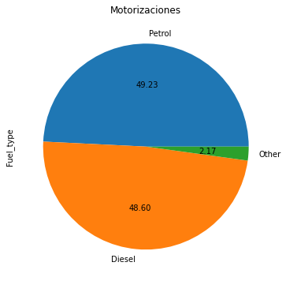

```python
df_anuncios_clean['Fuel_type'].value_counts().plot(kind='pie', autopct='%.2f', figsize=(6,6), title ='Motorizaciones')
```

```python
full_df = pd.merge(df_anuncios_clean, df_versiones_grouped,  how='left', left_on=['Genmodel_ID', 'Reg_year', 'Fuel_type'], right_on=['Genmodel_ID', 'Reg_year', 'Fuel_type'])
```

```python
full_df.dropna(inplace=True)
```

```python
full_df
```

|  | Genmodel_ID | Adv_ID | Reg_year | Bodytype | Runned_Miles | Engin_size | Gearbox | Fuel_type | Engine_power | Annual_Tax | ... | Length | Average_mpg | Top_speed | Seat_num | Door_num | Ad_Date | Price_USD | Price | Gas_emission | Engine_size |
| --- | --- | --- | --- | --- | --- | --- | --- | --- | --- | --- | --- | --- | --- | --- | --- | --- | --- | --- | --- | --- | --- |
| 0 | 10_1 | 10_1$$2 | 2002.0 | Saloon | 44000 | 6.8 | Automatic | Petrol | 450.0 | 315.0 | ... | 5390.0 | 13 | 179 | 5.0 | 4.0 | June2018 | 38195.961 | 172529.1 | 426.0 | 6750.0 |
| 1 | 10_1 | 10_1$$12 | 2002.0 | Saloon | 52000 | 6.8 | Automatic | Petrol | 450.0 | 315.0 | ... | 5390.0 | 13 | 179 | 5.0 | 4.0 | June2018 | 35857.704 | 172529.1 | 426.0 | 6750.0 |
| 2 | 10_1 | 10_1$$3 | 2002.0 | Saloon | 55000 | 6.8 | Automatic | Petrol | 400.0 | 315.0 | ... | 5390.0 | 14 | 155 | 5.0 | 4.0 | November2017 | 39418.277 | 172529.1 | 426.0 | 6750.0 |
| 3 | 10_1 | 10_1$$6 | 2002.0 | Saloon | 55000 | 6.8 | Automatic | Petrol | 450.0 | 315.0 | ... | 5390.0 | 13 | 179 | 5.0 | 4.0 | December2017 | 32929.723 | 172529.1 | 426.0 | 6750.0 |
| 4 | 10_1 | 10_1$$14 | 2002.0 | Saloon | 58000 | 6.8 | Automatic | Petrol | 450.0 | 315.0 | ... | 5390.0 | 13 | 179 | 5.0 | 4.0 | July2018 | 34320.486 | 172529.1 | 426.0 | 6750.0 |
| ... | ... | ... | ... | ... | ... | ... | ... | ... | ... | ... | ... | ... | ... | ... | ... | ... | ... | ... | ... | ... | ... |
| 280422 | 96_9 | 96_9$$248 | 2012.0 | Estate | 94000 | 1.6 | Manual | Diesel | 113.0 | 30.0 | ... | 4522.0 | 65 | 121 | 5.0 | 5.0 | July2018 | 7902.308 | 25511.805556 | 133.583333 | 1866.222222 |
| 280423 | 96_9 | 96_9$$513 | 2012.0 | Estate | 95000 | 1.6 | Manual | Diesel | 113.0 | 0.0 | ... | 4522.0 | 74 | 121 | 5.0 | 5.0 | May2018 | 8014.938 | 25511.805556 | 133.583333 | 1866.222222 |
| 280424 | 96_9 | 96_9$$169 | 2012.0 | Estate | 96060 | 1.6 | Manual | Diesel | 113.0 | 30.0 | ... | 4522.0 | 65 | 121 | 5.0 | 5.0 | October2017 | 8446.423 | 25511.805556 | 133.583333 | 1866.222222 |
| 280425 | 96_9 | 96_9$$139 | 2012.0 | Estate | 96824 | 1.6 | Manual | Diesel | 113.0 | 0.0 | ... | 4522.0 | 74 | 121 | 5.0 | 5.0 | August2018 | 7171.432 | 25511.805556 | 133.583333 | 1866.222222 |
| 280426 | 96_9 | 96_9$$231 | 2012.0 | Estate | 99900 | 1.6 | Manual | Diesel | 113.0 | 0.0 | ... | 4522.0 | 74 | 121 | 5.0 | 5.0 | July2018 | 7260.866 | 25511.805556 | 133.583333 | 1866.222222 |

262942 rows × 23 columns